# Reporte de registros

Registros proporcionados por artesanas y artesanos participantes en el Encuentro de Arte Textil Mexicano ORIGINAL

## Aplicación y metodología

### Planteamiento

La propuesta de elaboración del **Atlas De Técnicas De Artes Textiles En Original** surgió ante la necesidad de reconocer, documentar y fortalecer la diversidad de técnicas textiles que existen en México, muchas de las cuales están en riesgo por la falta de registro, la desvalorización cultural y el debilitamiento de los procesos de transmisión intergeneracional.

Impulsada en el marco del Encuentro Nacional de Artes Textiles Original, esta iniciativa representa una oportunidad para promover formas participativas de consulta y registro que contribuyan a la salvaguardia de técnicas artesanales en todo el país, aprovechando la amplia convocatoria del evento.

Un atlas, construido de forma **participativa con artesanas y artesanos** de distintas regiones, podría convertirse en una herramienta clave para:

- Visibilizar saberes locales y formas de vida vinculadas al textil.
- Fortalecer redes comunitarias y procesos de salvaguardia.
- Orientar políticas públicas culturales desde las voces de quienes practican estas técnicas.

**Es importante destacar que este atlas no pretende ser exhaustivo, sino representar una muestra de la diversidad técnica del arte textil en México. Su estructura y contenido permanece abierto, por lo que podrá enriquecerse con futuras experiencias, registros y actividades.**

### Técnicas del arte textil

Son los diversos métodos usados en la elaboración y manipulación de telas y tejidos y que son esenciales para producir prendas de vestir, decoración de interiores y otros productos textiles. Se pueden consideran tres categorías principales:

- El bordado
- El tejido
- El teñido

#### El bordado

El bordado artesanal es una actividad artística y cultural, que se realiza sobre telas tejidas o de otros soportes flexibles (cuero, plástico) usando agujas e hilos, que, mediante puntadas sobre la tela o puntadas tejidas, forman motivos y diseños artísticos o decorativos. Pueden incorporarse perlas, abalorios o lentejuelas.

**¿Cuántas técnicas encontramos en el bordado y que se define como técnica?**

- De acuerdo a la forma cómo se realiza existen 2 técnicas: bordado de mano y bordado de máquina en donde tenemos las máquinas de pedal y las máquinas de motor. Ambas son artesanales porque dependen para realizarse de las bordadoras implicando una coordinación de los movimientos de las manos, del pie y evidentemente de la vista y del cerebro.
- En cuanto a puntadas, existen, acorde a registros que se han realizado, más de 300 puntadas en el mundo, considerando las 2 técnicas: mano y máquina.
- Sin embargo, hay quienes consideran que cada puntada es una técnica y se habla de más de 300 técnicas en el mundo.

En el ejercicio, las puntadas las consideramos como técnicas del bordado y en ese sentido cada puntada será considerada como una técnica.

#### El tejido

El tejido artesanal es una actividad artística cuyas técnicas implican el inter lazado de hilos para crear prendas o telas. Pueden realizarse a mano o con telares de cintura o mecánicos o de pedal.

**¿Cuántas técnicas encontramos en el tejido y que se define como técnica?**

- De acuerdo a la forma como se realiza existen:
- El tejido a mano que puede ser con de punto (con dos agujas y estambre o hilo) y de crochet (con ganchillo y estambre o hilo)
- El tejido en telar puede ser:
- Con telar de cintura usando hilos de algodón o de lana naturales o con hilos sintéticos
- Con telar de pedal o mecánico usando algodón o lana naturales o sintéticos.

#### El teñido

El Teñido artesanal es una actividad artística artesanal que consiste en añadir color a los tejidos para cambiar su apariencia. Hay dos técnicas a considerar:

- Teñido con tintes naturales
- Teñido con tintes sintéticos

#### Diagrama

El siguiente diagrama presenta una estructura jerárquica de las principales técnicas artesanales empleadas en el arte textil en México, organizada en tres grandes categorías: bordado, tejido y teñido. Cada una de estas categorías se desglosa en subprocesos y variantes que reflejan la diversidad de métodos, herramientas y conocimientos tradicionales utilizados por las y los artesanos.

[interactive chart not shown]

> **En este Atlas, los registros de técnicas proporcionados por las artesanas y los artesanos de Original reflejan la variedad existente dentro de las dos categorías generales: bordado y tejido. Cada una de ellas se organiza a su vez en subgrupos —bordado a mano y bordado a máquina; tejido a mano y tejido en telar— para facilitar su análisis. Por su parte, el teñido se considera una técnica de aplicación transversal, es decir, puede incorporarse a cualquiera de los grupos anteriores. A lo largo de este instrumento se presenta la información derivada del registro de técnicas dentro de estas categorías y subcategorías.**

## Recolección de datos

Para la recolección de datos se diseñó una Ficha de Registro de Técnicas Textiles como herramienta para documentar, preservar y visibilizar los saberes textiles tradicionales. Esta ficha fue desarrollada en una plataforma digital para la recolección de datos, lo que permitió estructurar un formato flexible, accesible y eficiente para su aplicación en campo a través de dispositivos móviles.

La decisión de diseñar esta ficha respondió a la necesidad de contar con un instrumento que facilitara la sistematización de información directamente desde las voces de las personas artesanas, mediante entrevistas que recogen datos sobre procesos, significados, materiales y contextos sociales vinculados a cada técnica.

El contenido de la Ficha de Registro de Técnicas Textiles incluyó:

- Datos generales de la persona entrevistada (edad, género, ubicación, contacto).
- Identificación de la técnica, tanto en español como en lengua indígena.
- Ubicación geográfica de la práctica (estado, municipio, localidad).
- Características técnicas, como tipo de manufactura, uso de teñido y materiales empleados.
- Contexto cultural, incluyendo historia, creencias, significados, ceremonias.
- Prendas y eventos comunitarios donde se utiliza la técnica.
- Transmisión del conocimiento, con información sobre quién enseñó la técnica y transmisión.
- Material multimedia, como fotografías y videos que complementan el registro.

El ejercicio de levantamiento de fichas fue acompañado por una actividad de cartografía participativa, en la que las y los asistentes colocaban en un mapa expuesto en la sala las técnicas textiles que iban registrando.

Esta dinámica permitió visualizar la diversidad geográfica de los saberes compartidos, fomentar el intercambio entre regiones y fortalecer el sentido colectivo del patrimonio textil.

### Procesamiento

Como parte del procesamiento de la información recabada mediante las fichas de registro, se realizó una limpieza y estandarización de los datos, especialmente en los nombres de las técnicas textiles, utilizando criterios de coincidencia fonética y similitud técnica para facilitar su agrupación y análisis.

Posteriormente, se aplicaron herramientas de análisis basadas en lenguaje de código y sistemas de visualización geoespacial, lo que permitió explorar los datos, identificar patrones regionales y generar una serie de fichas analíticas por técnica, con hallazgos relevantes sobre su distribución, características, significados y formas de transmisión.

### Resumen de datos

Se recibieron un total de **638 aportaciones**, correspondientes a **516 participantes** en el ejercicio.

Las personas participantes provienen de **29 estados** y **205 municipios** del país.

En conjunto, se identificaron **161 técnicas**, las cuales se vinculan con **31 lenguas** registradas en los testimonios recopilados.

## Participación

### Participantes por sede

La siguiente gráfica presenta el número total de participantes registrados en cada una de las sedes de Original. Para cada sede se contabilizaron únicamente personas únicas, evitando duplicidades en caso de múltiples registros asociados al mismo participante.

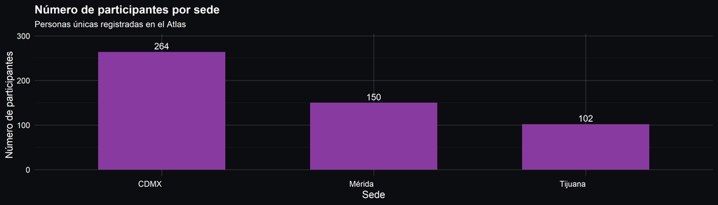

### Participantes por estado

El siguiente gráfico muestra la distribución de las personas participantes según su estado de procedencia. Se contabilizan participantes únicos, lo que permite visualizar en qué entidades federativas se concentró la mayor participación en el ejercicio

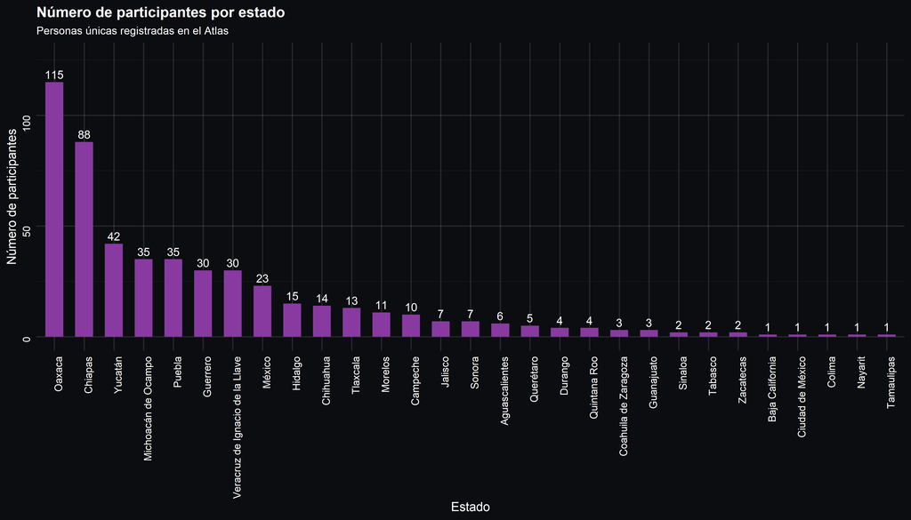

### Participantes por lengua indígena

Este gráfico presenta el número de participantes que se identifican con cada lengua indígena registrada en el ejercicio.

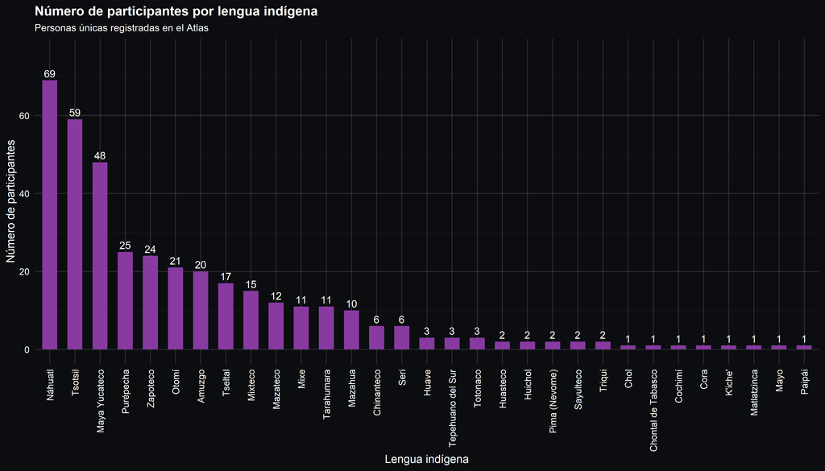

### Participantes por género

Se muestra la distribución porcentual de participantes según género.

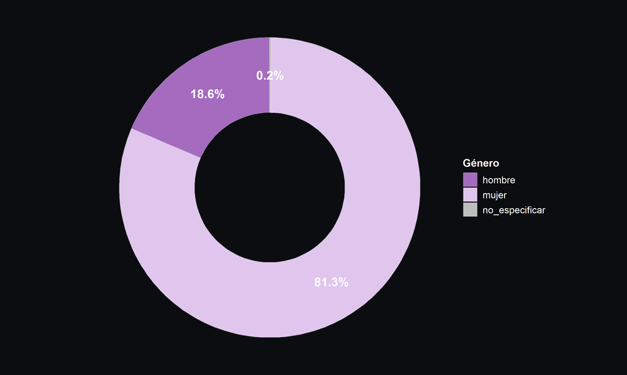

## Distribución geográfica

### Cantidad de técnicas registradas por demarcaciones

Ranking de estados con más técnicas distintas reportadas. Las etiquetas indican el total de técnicas por estado.

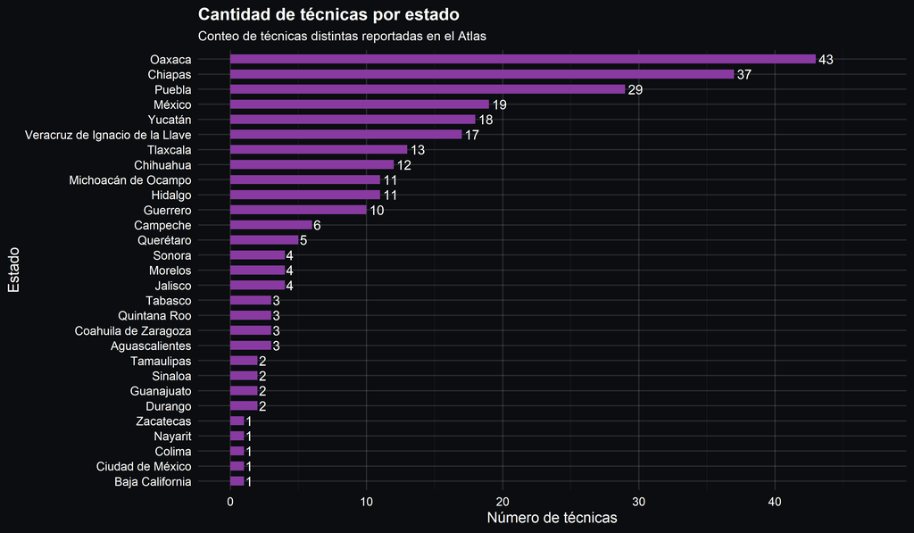

Este gráfico presenta los 20 municipios con el mayor número de técnicas distintas registradas dentro del Atlas.Cada barra representa la cantidad de técnicas identificadas en un municipio específico.

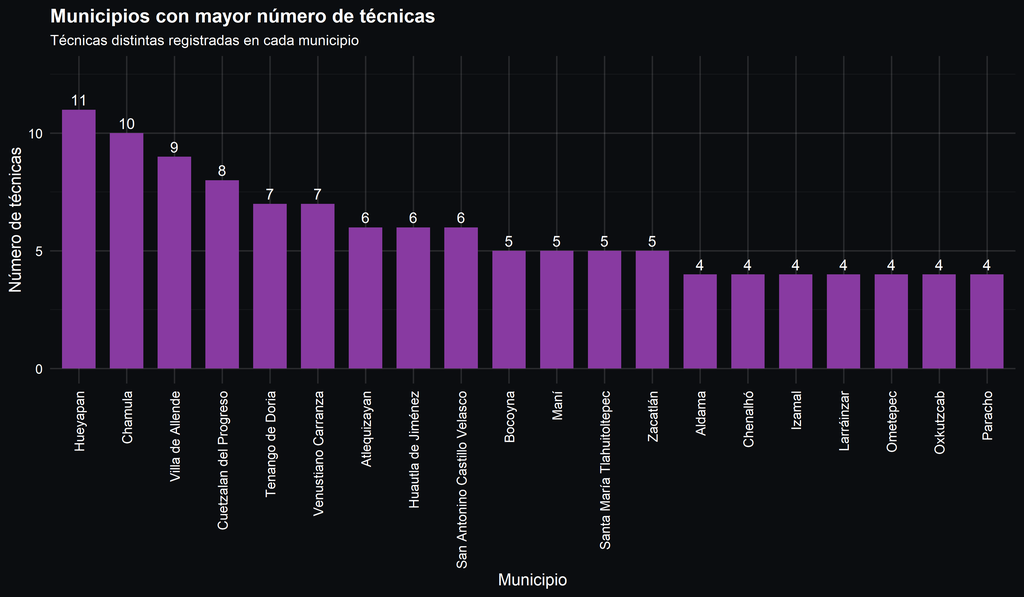

### Relación entre estados y técnicas

Flujos entre los 5 estados con más técnicas y las 10 técnicas más frecuentes. El ancho de cada flujo corresponde al número de registros compartidos.

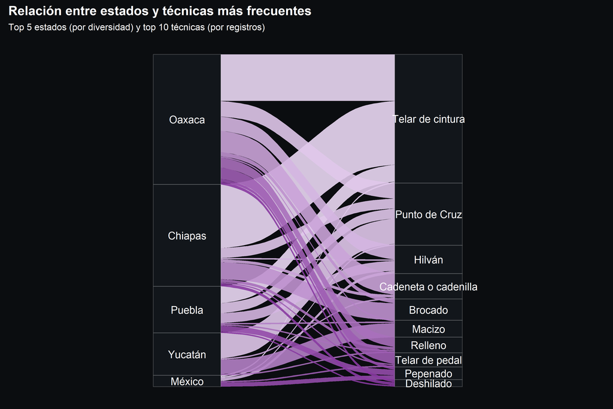

### Técnicas más comúnes

Para cada estado se presenta la técnica con mayor número de personas únicas que la reportan, ordenada por relevancia

| Estado | Técnica más común | Personas únicas |
| --- | --- | --- |
| Chiapas | Telar de cintura | 39 |
| Oaxaca | Telar de cintura | 33 |
| Yucatán | Punto de Cruz | 17 |
| Michoacán de Ocampo | Telar de cintura | 15 |
| Guerrero | Telar de cintura | 13 |
| Puebla | Telar de cintura | 12 |
| Veracruz de Ignacio de la Llave | Telar de cintura | 11 |
| Campeche | Punto de Cruz | 8 |
| Morelos | Telar de cintura | 7 |
| Aguascalientes | Deshilado | 4 |

[output cut: 19 more lines]

## Características de la técnica

### Distribución por técnica general

Participación porcentual de las técnicas generales. Las etiquetas muestran el porcentaje sobre el total.

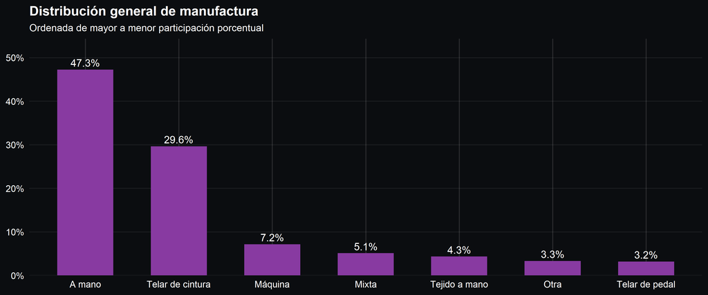

### Tipos de técnicas generales por estado

Composición relativa de las técnicas generales en cada estado. Permite comparar proporciones internas más que volúmenes absolutos.

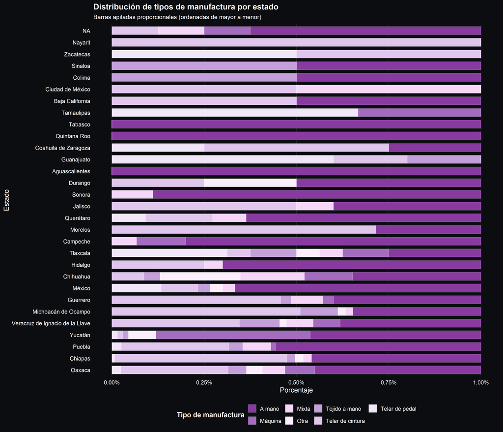

### Materiales

Los rectángulos representan los materiales más mencionados; su tamaño es proporcional a la frecuencia y la etiqueta incluye el porcentaje.

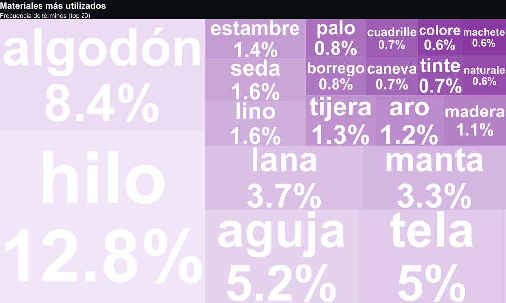

### Diversidad de técnicas por lengua indígena

La siguiente gráfica muestra la distribución relativa de las diez técnicas más frecuentemente registradas entre las distintas lenguas indígenas representadas en el Atlas.

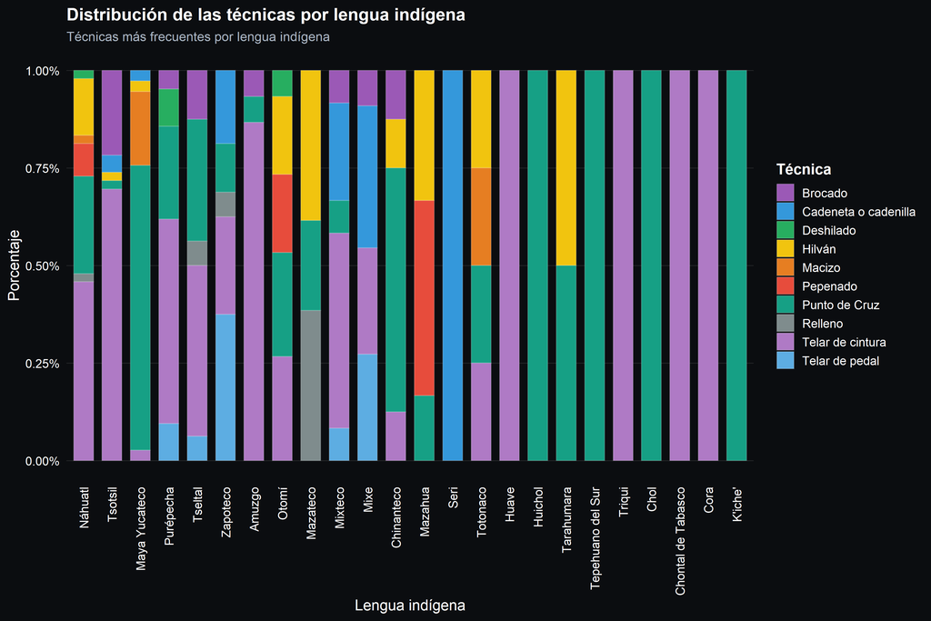

## Teñido

### Distribución general por tipo teñido

Este gráfico muestra la participación porcentual de los distintos tipos de teñido registrados en el Atlas. La visualización permite identificar claramente cuáles son las prácticas de teñido predominantes entre las personas portadoras de técnicas textiles.

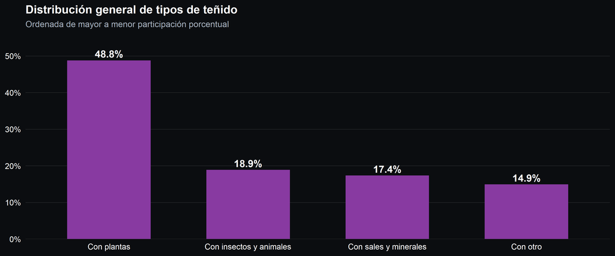

### Tipos de teñido por manufactura

La visualización, construida con barras horizontales apiladas al 100%, permite observar la proporcionalidad interna en cada tipo de manufactura, revelando patrones como:

- Qué procesos de teñido se asocian más frecuentemente con prácticas tradicionales.
- Qué técnicas de manufactura tienden a incorporar ciertos materiales para teñido.
- La diversidad de combinaciones entre métodos de producción y prácticas de teñido.

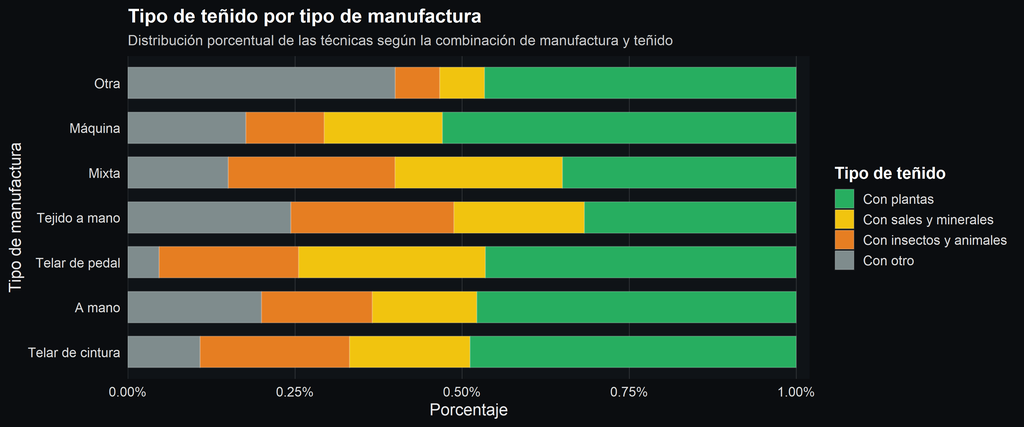

### Tipos de teñido por técnica

Cada barra horizontal normalizada al 100% permite comparar, entre técnicas, la importancia relativa de:

- teñido con plantas,
- teñido con sales y minerales,
- teñido con insectos y animales,
- otros métodos registrales.

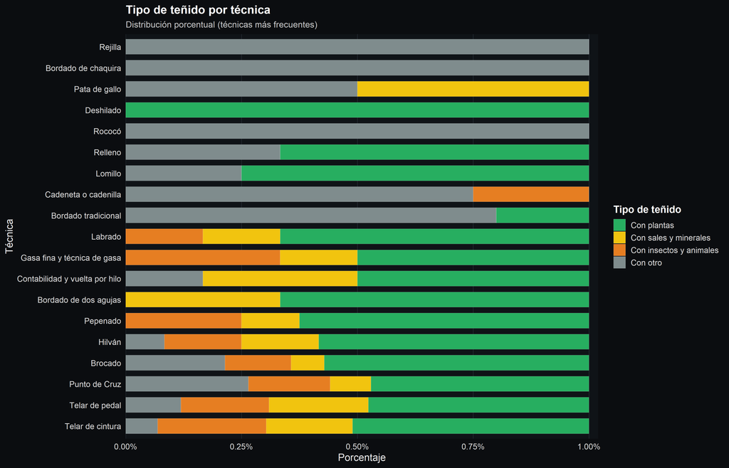

## Transmisión

### Aprendizaje

Distribución de las fuentes de aprendizaje reportadas. Los porcentajes se calculan sobre el total de respuestas.

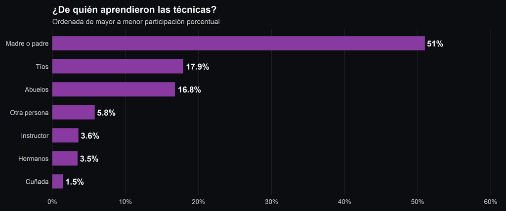

### Enseñanza

Destinatarios a quienes se transmite la técnica. Los porcentajes se calculan sobre el total de respuestas.

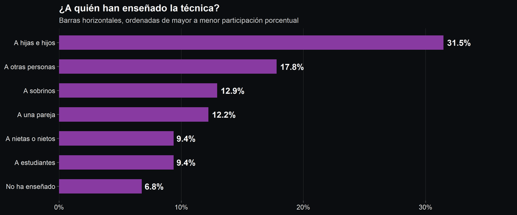

### Cadena de transmisión de saberes

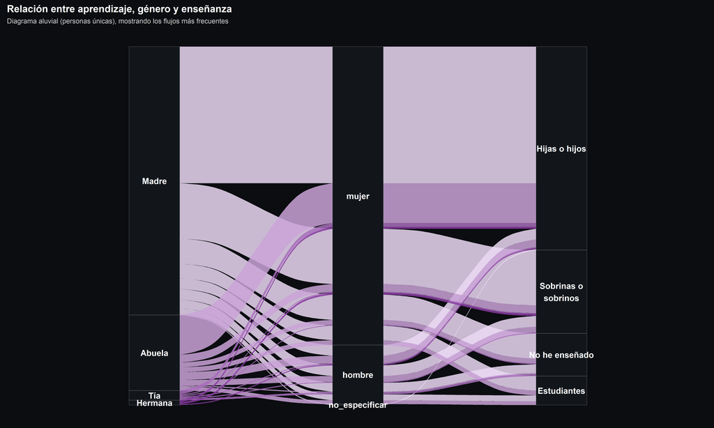

### Transmisión de saberes por género

La siguiente visualización muestra cómo las personas participantes transmiten sus saberes según su género. Las barras horizontales representan el 100% de las respuestas dentro de cada categoría de género, y los colores indican los distintos grupos a quienes han enseñado la técnica: hijas, hijos, nietos, estudiantes, pareja, entre otros.

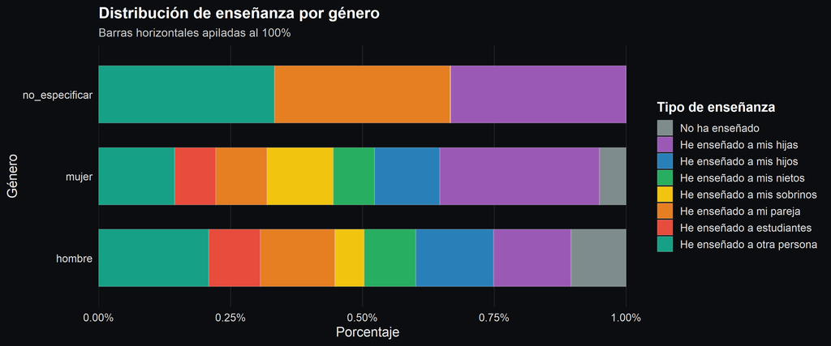

## Prendas

### Productos más frecuentes

La información recopilada en los registros permite identificar una amplia diversidad de prendas producidas mediante las técnicas textiles documentadas. A partir del análisis de los términos mencionados por las artesanas y artesanos se estimó el número aproximado de productos distintos elaborados en las comunidades participantes.

Se registraron aproximadamente **240 productos** distintos como parte del ejercicio.

Top de productos mencionados; el tamaño del recuadro refleja su frecuencia y la etiqueta muestra el porcentaje.

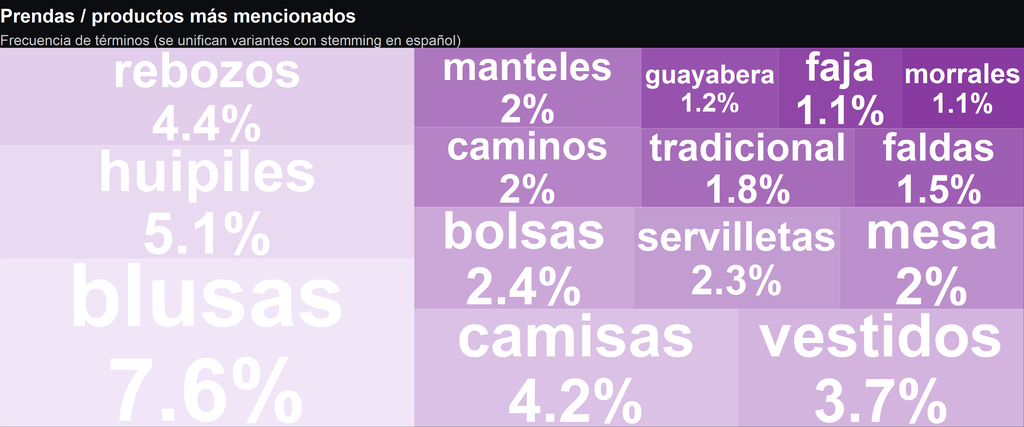

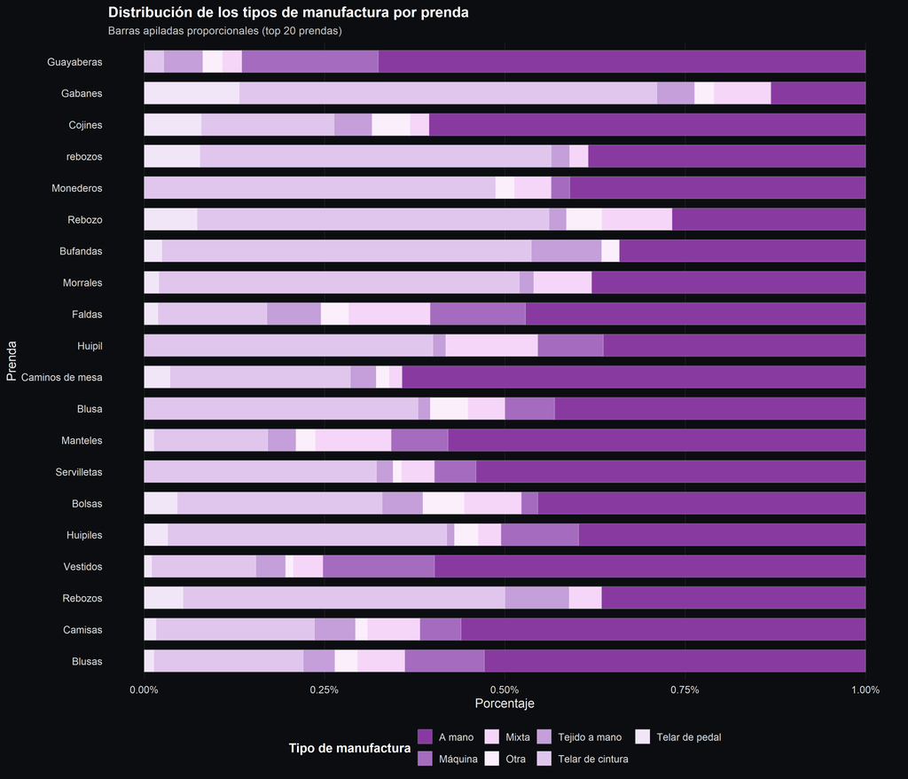

## Ceremonias

### Ceremonias asociadas a las técnicas

El diagrama aluvial muestra las conexiones más frecuentes entre los términos mencionados por las personas artesanas al describir ceremonias y las prendas que se utilizan en ellas. Los flujos ilustran cómo ciertos conceptos ceremoniales se vinculan recurrentemente con tipos específicos de indumentaria, permitiendo identificar patrones de uso, simbolismos compartidos y asociaciones tradicionales presentes en las prácticas textiles.

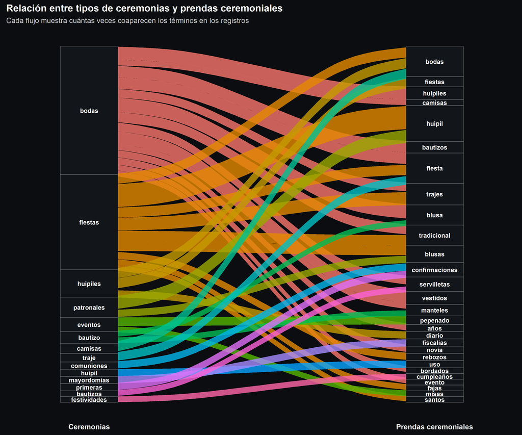

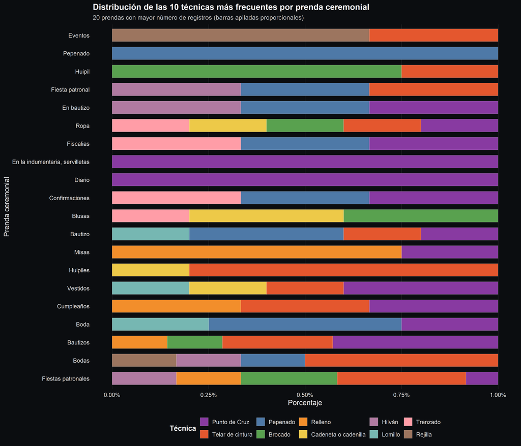